[figure not shown]

本文包括内容： 【如何计算乐曲的高潮所在的小节】【什么是音高】【协和音程中的数学】【三分损益律】

# 音乐？数学？有什么关系？

## 音乐的高潮，和数学有什么关系？

首先，先来说一个概念：黄金分割率。

在一个线段 $AB$ 中有一点 $C$ ，使得 $AC:BC=BC:AB$,这个比值就叫做【黄金分割比】，他的近似值是0.618.

通过下面的计算，我们就可以发现，如果 $a=0.618$,那么 $\dfrac{a}{1}=a,\dfrac{1-a}{a}=0.618$。

```python
from decimal import * #引入十进制运算库
a=Decimal(0.618) #给a赋值0.618
getcontext().prec=3
print("运行结果:")
a2=Decimal(a/1) #将a/1保存为a2
a3=(Decimal(1-a)/Decimal(a)) #将(1-a)/a保存为a3

if a2==a3: #如果两个值相等
    print("a2 = a3，这个值是",a2,",",a/1,"是黄金分割比")
else: #否则？
    print(a,"不是黄金分割比")
```

```
运行结果:
a2 = a3，这个值是 0.618 , 0.618 是黄金分割比
```

如果对黄金分割比感兴趣，可以自己去百度百科上找资料研究。在百度百科所写出的关于 **黄金分割比** 的内容中就有他与音乐的关系。

[figure not shown]

简而言之，一个乐谱的 **高潮部分** ，竟然可以用以下公式来计算!

设这首乐曲共有 $m$ 小节，那么高潮部分就在 $0.618m$ 小节处！（大约）

为了证明这个公式的准确性，我们可以找一个乐谱，比如钢琴考试 $10$ 级的《练习曲》

```python
%%html
<details>
  <summary>点我看乐谱，再点我收起</summary>
  <div>
<img style="transform: rotate(180deg);" width="400" height="300" src="https://s4.ax1x.com/2022/02/03/HVWe91.jpg" /> <!--69-->
<img style="transform: rotate(180deg);" width="400" height="300"src="https://s4.ax1x.com/2022/02/03/HVWm1x.jpg" /> <!--70-->
<img style="transform: rotate(180deg);" width="400" height="300"src="https://s4.ax1x.com/2022/02/03/HVWEN9.jpg" /> <!--71-->
<img style="transform: rotate(180deg);" width="400" height="300"src="https://s4.ax1x.com/2022/02/03/HVWVhR.jpg" /> <!--72-->
<img style="transform: rotate(180deg);" width="400" height="300"src="https://s4.ax1x.com/2022/02/03/HVWAAJ.jpg" /> <!--73-->
</div>
</details>
```

**点我看乐谱，再点我收起**

[figure not shown]

```python
%%html
<html>
<head>
<script>
function a() {
    xjs=parseInt(document.getElementById("calc").value);
    document.getElementById("block").innerHTML="<b>"+parseInt(xjs*0.618+0.5)+"</b>"
}
</script>
</head>
<body>
输入乐曲小节数&nbsp;<input id="calc" />
<button onclick="a()">提交计算</button><br /><br />
乐曲高潮所在的小节数: <div id="block">未计算</div>
</body>
</html>
```

输入乐曲小节数  
乐曲高潮所在的小节数:

未计算

输入了小节数 $69$ 后，你应该得到了四舍五入以后的小节值: $43$。

让我们观察第43节前后，应该得到这一段

[figure not shown]

上图是第 $43$ 节到第 $49$ 节的截图。可以看到，这个地方音符复杂，左手右手甚至有一对多的情况，毫无疑问就是高潮了。

事实上，本曲的高潮开始于第 $38$ 节。这个计算方法虽然存在一定误差，但是确实可以**较为精准**地找到一首曲子的高潮。

**理论存在，实践证明成功!**

关于这个理论成立原因，现有的资料把它归结于 **奇妙的巧合**,而由于历史原因，真正的原因就不得而知了。

第一个课题的研究基本上已经完毕，接下来我们来看一些更有意思的事儿。

## 音高？比的原理

### Basic

> 钢琴上每七个白键一个循环，分别叫做CDEFGAB(为何不是从A开始，而是从C开始？这是个历史问题。。。)，也就是我们熟知的”Do Re Mi Fa So La Si”，过了一个循环就下标加一，又叫升八度，即，C1, C2, C3, C4…

看着很难理解，但是让我们看回文章开始的那个图

[figure not shown]

我们所熟悉的"Do,Re,Mi",用音名来表示为“C,D,E".而国际标准音是 **La** ,也就是 **A** 音。考乐理的时候，有一个环节是考官用钢琴弹一段乐谱，考生需要将这个乐谱在五线谱上画出来。而在考官弹奏乐谱之前，会先来弹奏一个 **La** 音，旨在为考生找到正确的音高。

### 高八度？低八度？”八度"有什么意义？

经常听说高八度，低八度，而"八度"是什么呢？这就要从【音高】说起。

> 音的高低是由振动频率决定的，两者成正比关系：振动频率高则音”高”，反之则”低”。

查找资料发现，【音高】和【振动频率】成正比，那我们就来看看一些常见的音的"频率".

刚刚说了，标准音是 **La** 音，即标准音高。而这个 **La**可不是键盘上的任意一个 **La** ，它的音高是 $A^4$,即 $440Hz$.

那么，了解完了【音高】和【频率】，我们就可以触及正题【八度】了。

简单的来说，高八度的音，【频率】翻一倍。

### 协和音程？这和比有什么关系？

了解完了一些基本概念，我们就可以把它和 **数学** 结合起来了。

如果你在钢琴键盘上面 **乱敲** ，你极有可能敲出一些 **不协和音程** 。

问题来了，要让一组音（包含的音符数量 $0 \le x\le 2$) **柔和+动听** ，我们应该怎么来搭配音高呢？

首先，如果你只敲一个音，也就不存在什么 **动听不动听**.换句话说，这组音中两个音的频率值比是 $1:1$ 。

如果你同时弹奏 $A^4$(中央La) 与 $A^5$(高音La) ，他们仍然是十分协和的

我国明朝音乐家朱载堉发明的 **十二平均律** 之中规定:

> $A^4$与$A^5$之间的频率比是1:2。 一个八度被分为12个半音，一个半音被细分为100个音分。

后面的内容可以暂且不论，我们可以知道我们如果弹奏这组音 ${A^4,A^5}$ ，频率之比为 $1:2$.

因为 $A^4$ 是440Hz,那么 $A^5$ 是880Hz.

不仅限于 $A^4$ 和 $A^5$ ，事实上所有的纯八度，频率比为 $1:2$ ，也是协和音程.

但是，听起来比较协和的音程，不仅仅有以上两种.

弹奏 $\{C^3,F^3\}$，你会觉得它也是协和的.

根据查找，$C^3$ 是261.626Hz ,$F^3$:349.228Hz。

让我们计算他们的频率值比

```python
from decimal import *
getcontext().prec=8
res=Decimal('261.626')/Decimal('349.228')
print(res.quantize(Decimal('0.0000')))
```

```
0.7492
```

他们的比值居然正好是 $\dfrac{3}{4}$！（当然，误差是有的）

那么当然，在我们的认知中，$\{C^3,G^3\}$ 也是协和的。

查表，$G^3$:391.995Hz

```python
from decimal import *
getcontext().prec=8
res=Decimal('261.626')/Decimal('391.995')
print(res.quantize(Decimal('0.0000')))
```

```
0.6674
```

发现巧妙之处了吗？没错！这次是$\dfrac{2}{3}$！其实我们上面算的都是 **（极）完全协和音程**。现在，我们可以得出结论了

极完全协和音程，两个音频率之比为 $1:1$ 或 $1:2$ ；

完全协和音程，两个音频率之比为 $3:4$ 或 $2:3$。

我们用计算机的计算证明了，人类认为"非常协和"的音程，频率之比就是 1:1,1:2,2:3,3:4四种。

当然，还有一些不完全协和音程...这些这里就不计算了。通过这次计算，我们知道了人们听着顺耳的音，居然也和比有关系。

### 延伸拓展

我们已经证明了以上规律，是否可以拿来做一些更有意思的事情呢？

例如，我们把上面发现的几个比按比值大小排序：

$ 1:1 , 1:2 , 2:3 , 3:4$

那么我们可以想象以下，如果是 $4:5$会如何

毕竟按照这个规律 ($1:1$ 无视)，接下来就应该是$4:5$嘛。

首先，中央 $C$ 的频率是 $261.626$，我们来计算一下第二个音的频率值.

```python
from decimal import Decimal,getcontext

C=Decimal('261.626') # 中央C
nibanme_oto=C/4*5

print(nibanme_oto.quantize(Decimal('0.0000')))
```

```
327.0325
```

经过查表，没有对应 $327.0325Hz$ 的音。但是我们可以看一看下图。

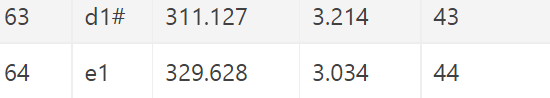

那么我们可以再试试 $5:6$?

```python
from decimal import Decimal,getcontext

getcontext().prec=8
C=Decimal('261.626') # 中央C
nibanme_oto=C/5*6

print(nibanme_oto.quantize(Decimal('0.0000')))
```

```
313.9512
```

可以看到，这个值和 $D^3\#$ 更接近了。

由于篇幅原因，就不继续延伸了。

## 古代的吹管乐器中的数学原理

### 从一个共鸣器开始

我们知道，开管空气柱振动频率的计算公式是 $f=\dfrac{c}{2l}$。其中$f$表示频率，$c$表示声速，$l$表示空气柱的长度。

这个公式表明空气柱的振动频率 f 与长度 l 成反比，其中 c 为声速。这种比例关系与弦振动频率与长度的关系类似，都是通过改变长度调节振动的频率。

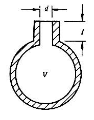

这个共鸣器是 【亥姆霍兹(H. von Helmholtz,1821~1894)】设计的，是吹管乐器的理想模型。

以上是外国的成就，下面我们来说说中国的

### 什么是三分损益律？

我们刚刚在研究协和音的时候已经说过:

【如果一个音的波长为a ；另一个音的波长是a/2 的话，那么，后一个声音就是前一个声音的“纯八度”高音。同理，如果一个声音的波长为a ，另一个声音的波长为a的两倍，即2a，那么，后一个声音就是前一个声音的“纯八度”低音。】

没错，中国古人虽然不懂得机械波的物理学理论，但是他们却总结出了跟现代发声理论完全一致的道理。一件圆径固定，长度固定的发声器所发出的声音是一个定值，如果另一件圆径相同发声器的长度是这件发声器长度的一半的话，那么，另一件发声器所发出的声音，就是一个纯八度的高音。同理，如果另一件发声器的长度是原来发声器长度的二倍，那么，另一件发声器所发出的声音，就是一个纯八度的低音。 中国古人所使用的音阶是“五声音阶”，即“宫商角 徵羽”五个音。其中，宫相当于西洋音阶的1（do），商相当于2（re），角相当于3（mi）， 徵相当于5（sol），羽相当于6（la）。

在这个基础上，古人发明了 我国古代著名的“**三分损益法**”！

> 三分损益法是古代中国发明制定音律时所用的生律法。根据某一标准音的管长或弦长，推算其余一系列音律的管长或弦长时，须依照一定的长度比例，三分损益法提供了一种长度比例的准则。 中国音乐有悠久的历史和独特的创造。秦以前，中国已创造了乐器和乐曲，发明了乐律。汉唐盛世，中国音乐以歌舞音乐见长；宋元以后，则以戏曲音乐为主。当今世界公认的音乐律制，如五度相生律（中国称三分损益律）、纯律和十二平均律，中国皆独立发明。 [1] --Adapted from Baike

三分损益包含“三分损一”、“三分益一”两层含义。三分损一是指将原有长度作3等分而减去其1份，即：$原有长度 \times \frac{3-1}{3}=生得长度$；而三分益一则是指将原有长度作3等分而增添其1份，即：$原有长度 \times \frac{3+1}{3}=生得长度$。两种方法可以交替运用、连续运用，各音律就得以辗转相生。

可能有点难以理解，那我们继续往下看看

以一段圆径绝对均匀的发声管为基数——宫（$do$）；然后，将此发声管均分成三段，舍弃其中的一段保留二段，这就是“三分损一”，余下来的三分之二长度的发声管所发出的声音，就是“宫”的纯五度高音—— 徵（$sol$）；将 徵管均分成三份，再加上一份，即 徵管长度的三分之四，这就是“三分益一”，于是就产生了 徵的纯四度低音——商（$re$）；商管保留三分之二，“三分损一”，于是得出商的纯五度高音——羽（$la$）；羽管“三分益一”，即羽管的三分之四的长度，就是角管，角管发出羽的纯四度低音——角（$mi$）。

简单的画个图来理解一下

[figure not shown]

✔1 就像这样，三等分笛子以后在 $\dfrac{2}{3}$ 处找到 $sol$ 音

[figure not shown]

✔2 三等分以后在 $\dfrac{4}{3}$ 处找到 $re$ 音

以 $re$ 为起点重复✔1操作，得到 $la$ 音

以 $la$ 为起点重复✔2操作，得到 $mi$ 音。

这样“损益”下去就可以得到所有音符。

### 一切还没有结束

让我们来验证一下这个事实（三分损益法的损益可以生成一些什么音符）

使用这个公式。 $f=\dfrac{c}{2l}$。

如果理论正确，损益 $12$ 次就会得出12个常用音名（程序中为了防止误差，将误差容许值设置为15Hz）

```python
from decimal import *

getcontext().prec=8

字典={'C':Decimal('261.626'),'C#':Decimal('277.183'),'D':Decimal('293.665'),'D#':Decimal('311.127'),'E':Decimal('329.628'),'F':Decimal('349.228'),'F#':Decimal('369.994'),'G':Decimal('391.995'),'G#':Decimal('415.305'),'A':Decimal('440.000'),'A#':Decimal('466.164'),'B+1':Decimal('493.883'),'B+1#':Decimal('523.251'),'C+1#':Decimal('554.365'),'D+1':Decimal('587.330'),'D+1#':Decimal('622.254'),'E+1':Decimal('659.255'),'E+1#':Decimal('698.456')}
结果=[]
def 操作(i,sy='损'):
    print('第',int(i*2),'次笛子长度',LEN.quantize(Decimal('0.000')),'本次操作模式',sy)
    #f=c/2l
    freq=SPD/(2*LEN)
    print('频率',(freq).quantize(Decimal('0.000')))
    for k,v in 字典.items():
        if abs(v-freq.quantize(Decimal('0.000')))<=Decimal('15'):#只要不超过15Hz就认定为相等
            print('对应音符:',k)
            结果.append(k)
#假设这个do是中央C
C=Decimal('261.626')
#声速是340m/s
SPD=Decimal('340')
#l=c/（2*f）
LEN=SPD/(2*C)
print("原先笛子长度:",LEN.quantize(Decimal('0.000')))
print("频率",C)
print("对应音符:","C")
for i in range(1,7):#12次:
    #损一次
    LEN=LEN/3*2
    操作(i-0.5)
    #益一次
    LEN=LEN/3*4
    操作(i,'益')
print('######分割线######')
print('最后结果：生成的音符有：')
for i in 结果:
    print(i,end=' ')
```

```
原先笛子长度: 0.650
频率 261.626
对应音符: C
第 1 次笛子长度 0.433 本次操作模式 损
频率 392.439
对应音符: G
第 2 次笛子长度 0.578 本次操作模式 益
频率 294.329
对应音符: D
第 3 次笛子长度 0.385 本次操作模式 损
频率 441.494
对应音符: A
第 4 次笛子长度 0.513 本次操作模式 益
频率 331.120
对应音符: E
第 5 次笛子长度 0.342 本次操作模式 损
频率 496.681
对应音符: B+1
第 6 次笛子长度 0.456 本次操作模式 益
频率 372.510
对应音符: F#
第 7 次笛子长度 0.304 本次操作模式 损
频率 558.766
对应音符: C+1#
第 8 次笛子长度 0.406 本次操作模式 益
频率 419.074
对应音符: G#
第 9 次笛子长度 0.270 本次操作模式 损
频率 628.611
对应音符: D+1#
第 10 次笛子长度 0.361 本次操作模式 益
频率 471.459
对应音符: A#
第 11 次笛子长度 0.240 本次操作模式 损
频率 707.188
对应音符: E+1#
第 12 次笛子长度 0.321 本次操作模式 益
频率 530.391
对应音符: B+1#
######分割线######
最后结果：生成的音符有：
G D A E B+1 F# C+1# G# D+1# A# E+1# B+1#
```

以上，生成的音符有 【G D A E B+1 F# C+1# G# D+1# A# E+1# B+1# 】十二个。

我们可以观看【三分损益法-百度百科】：

【古人使用“三分损益法”，在生成“宫、 徵、商、羽、角”五个音阶之后，并没有停止下来，而是继续“损益”下去。“三分损一”，“三分益一”……在连续进行了各六次之后，共得出十二个音，就是我们音乐上所使用的一个八度之内的十二个半音。中国古人将这十二个半音音阶称为“十二律”，它们的名称分别是： 黄钟（C），林钟（G），太簇（D），南吕（A），姑冼（E），应钟（B），蕤宾（#F），大吕（#C），夷则（#G），夹钟（#D），无射（#A），仲吕（#E）。】

需要一提的是，【B+1#】等同于【C+1】。

可以看到，生成的完全一致。三分损益法证明正确。

=======The End=======

所有知识来源于【中国音乐学院：基本乐理考级教程】&【百度百科】

技术展现内核 ：【Jupyter Notebook x Python 3.9】

Author：【IamFettgo】

2022/2/4 20:26 复核确认无误。

更多 Notes:https://Aimo-hux.github.io/Jupyter